# Detección GBM - analisis de los factores de riesgo

```r
library(jsonlite)
library(corrplot)
library(Amelia)
library(caret)
library(e1071)
library(survival)
library(ranger)
library(mice)
library(RColorBrewer)
library(gridExtra)
library(ggplot2)
library(ggpmisc)
library(data.table)
library(tibble)
```

Este script muestra los pasos seguidos para el análisis de los factores de riesgo que pueden llevar al desarrollo de un glioblastoma multiforme (GBM) y no sobrevivir.

```r
load(file = 'dataset_risk.Rda')

dataset_risk$cause_of_death <- as.factor(dataset_risk$cause_of_death)
dataset_risk$vital_status <- as.factor(dataset_risk$vital_status)
dataset_risk$gender <- as.factor(dataset_risk$gender)
dataset_risk$tumor_site <- as.factor(dataset_risk$tumor_site)
```

## EXPLORATORY DATA ANALYSIS

En este dataset se diferencian tres variables de clase distintas: cause_of_death o la causa de la muerte, vital_status o el estado del paciente (vivo/muerto) y life_expectancy o los dias que han pasado desde el diagnóstico del GBM hasta su muerte.

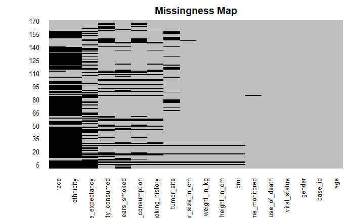

```r
# Missing values
missmap(dataset_risk, col=c("black", "grey"), legend=FALSE)
```

```r
cause_of_death_index <- which(names(dataset_risk) == 'cause_of_death', arr.ind = TRUE)
vital_status_index <- which(names(dataset_risk) == 'vital_status', arr.ind = TRUE)
life_expectancy_index <- which(names(dataset_risk) == 'life_expectancy', arr.ind = TRUE)

# Elminar las entradas con más del 30% de las variables con NA
# Tamaño del dataset antes de eliminar entradas
dim(dataset_risk)
```

```
[1] 170  18
```

```r
dataset_risk <- dataset_risk[which(rowMeans(!is.na(dataset_risk)) > 0.7), ]
# Eliminar variables con más del 30% de los valores con NA
dataset_risk <- cbind(dataset_risk[, which(colMeans(!is.na(dataset_risk[,-c(cause_of_death_index, vital_status_index, life_expectancy_index)])) > 0.7)], dataset_risk[,c(cause_of_death_index, vital_status_index, life_expectancy_index)])

cause_of_death_index <- which(names(dataset_risk) == 'cause_of_death', arr.ind = TRUE)
vital_status_index <- which(names(dataset_risk) == 'vital_status', arr.ind = TRUE)
life_expectancy_index <- which(names(dataset_risk) == 'life_expectancy', arr.ind = TRUE)

numeric_var_indexes <- c(which(sapply(dataset_risk, class) == 'numeric', arr.ind = TRUE), which(sapply(dataset_risk, class) == 'integer', arr.ind = TRUE))
numeric_var_indexes <- numeric_var_indexes[-which(numeric_var_indexes ==  life_expectancy_index, arr.ind = TRUE)]

non_numeric_var_indexes <- which(sapply(dataset_risk, class) == 'factor', arr.ind = TRUE)
non_numeric_var_indexes <- non_numeric_var_indexes[-which(non_numeric_var_indexes ==  cause_of_death_index, arr.ind = TRUE)]
non_numeric_var_indexes <- non_numeric_var_indexes[-which(non_numeric_var_indexes ==  vital_status_index, arr.ind = TRUE)]

# Tamaño del dataset tras eliminar entradas
dim(dataset_risk)
```

```
[1] 158  16
```

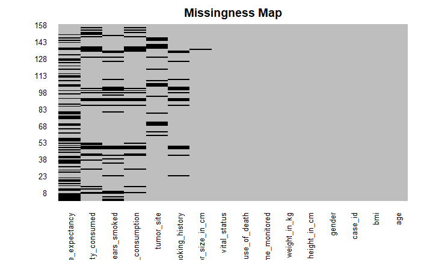

```r
missmap(dataset_risk, col=c("black", "grey"), legend=FALSE)
# Histogramas de las variables numéricas
par(mfrow=c(1, 4))
```

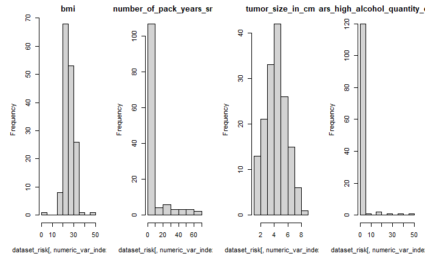

```r
for(i in 1:length(numeric_var_indexes)) {
    hist(dataset_risk[,numeric_var_indexes[i]], main=names(dataset_risk)[numeric_var_indexes[i]])
}
```

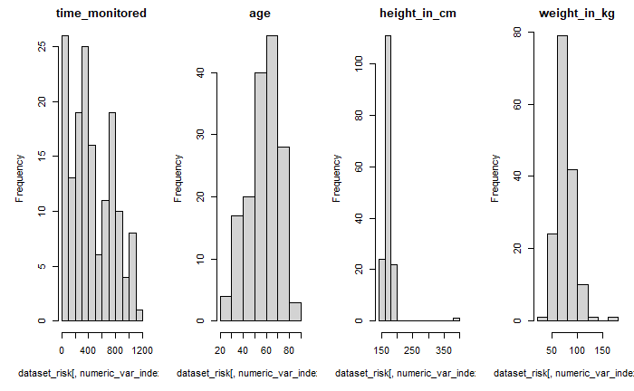

```r
# Barplots de las variables no numéricas
par(mfrow=c(1, 3))
```

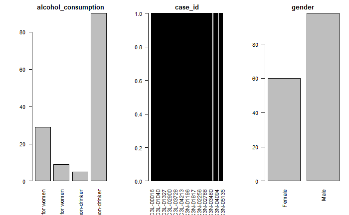

```r
for(i in 1:length(non_numeric_var_indexes)) {
    barplot(table(dataset_risk[,non_numeric_var_indexes[i]]), main=names(dataset_risk)[non_numeric_var_indexes[i]], las=2)
}
```

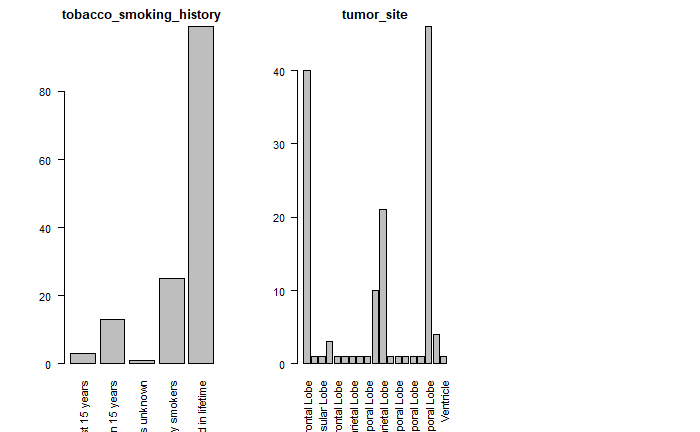

```r
# Correlación de las variables numéricas
par(mfrow=c(1, 1))
```

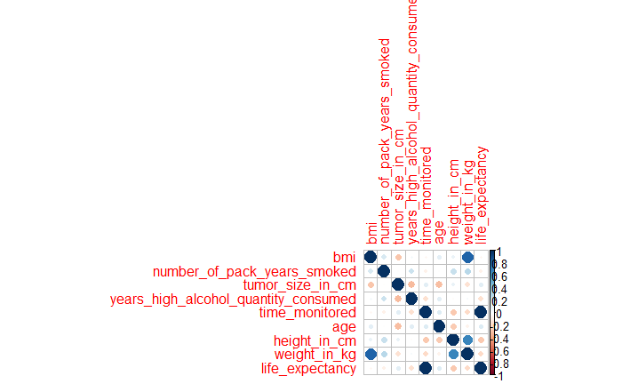

```r
correlation_numeric_vars <- cor(dataset_risk[, c(numeric_var_indexes, life_expectancy_index)], use = "complete.obs")
corrplot(correlation_numeric_vars, method="circle")
```

```r
# Valores del skewness
for(i in 1:length(numeric_var_indexes)){
  print(names(dataset_risk)[numeric_var_indexes[i]])
  print(skewness(dataset_risk[, numeric_var_indexes[i]], na.rm = TRUE))
}
```

```
[1] "bmi"
[1] 0.008604787
[1] "number_of_pack_years_smoked"
[1] 2.390884
[1] "tumor_size_in_cm"
[1] 0.07830985
[1] "years_high_alcohol_quantity_consumed"
[1] 5.442951
[1] "time_monitored"
[1] 0.340591
[1] "age"
[1] -0.4034307
[1] "height_in_cm"
[1] 8.426659
[1] "weight_in_kg"
[1] 0.9757215
```

De los datos extraidos en este punto se han realizado las siguientes observaciones.